# ml_notebook_v2

**Machine Learning Notebook**

```python
import pandas as pd
import numpy as np

import matplotlib.pyplot as plt
import seaborn as sns

import os
```

#### Custom Functions for later use

```python
# custom function for model comparison results when using gridsearch to identify high-performing models
def model_comp_results(model_input):
    # Get results from model comparison
    results = pd.DataFrame(model_input.cv_results_, columns=['param_classifier','mean_test_score'])

    # Round results and sort in descending order
    results['mean_test_score'] = round(results['mean_test_score'], 3)
    results = results.sort_values(by='mean_test_score', ascending=False)
    return results
```

```python
from sklearn.metrics import roc_auc_score
# Create ROC_AUC scoring function
def get_roc_auc(fitted_model):
    output = roc_auc_score(y_test, fitted_model.predict_proba(X_test)[:, 1])
    print('AUC-ROC: %.3f' % output)
```

## Import Data

```python
os.getcwd()
```

```
'/home/ad-frazier'
```

```python
os.chdir('/home/ad-frazier/data_science/ggu/summer_22/msba_326/326_final_project/')
```

```python
df = pd.read_pickle('./data/df_cleaned.pkl')
```

```python
df.info()
```

```
<class 'pandas.core.frame.DataFrame'>
RangeIndex: 12330 entries, 0 to 12329
Data columns (total 18 columns):
 #   Column                   Non-Null Count  Dtype
---  ------                   --------------  -----
 0   administrative           12330 non-null  int32
 1   administrative_duration  12330 non-null  float64
 2   informational            12330 non-null  int32
 3   informational_duration   12330 non-null  float64
 4   productrelated           12330 non-null  int32
 5   productrelated_duration  12330 non-null  float64
 6   bouncerates              12330 non-null  float64
 7   exitrates                12330 non-null  float64
 8   pagevalues               12330 non-null  float64
 9   specialday               12330 non-null  float64
 10  month                    12330 non-null  category
 11  operatingsystems         12330 non-null  category
 12  browser                  12330 non-null  category
 13  region                   12330 non-null  category
 14  traffictype              12330 non-null  category
 15  visitortype              12330 non-null  category
 16  weekend                  12330 non-null  category
 17  revenue                  12330 non-null  category
dtypes: category(8), float64(7), int32(3)
memory usage: 915.8 KB
```

**First 5 Features represent the number of different types of pages visited by the visitor in that session and total time spent in each of these page categories.**

```python
df.revenue.value_counts()
```

```
False    10422
True      1908
Name: revenue, dtype: int64
```

We note a slight class inbalance of 1:5 true vs false. This will likely come into consideration later on.

### ML Step 1: Set up data preparation steps in Pipeline

- One-Hot Encode Categorical Values
- Normlize Numeric Values
- Pipelines Tutorial: https://medium.com/vickdata/a-simple-guide-to-scikit-learn-pipelines-4ac0d974bdcf

```python
from sklearn.compose import ColumnTransformer
from sklearn.preprocessing import StandardScaler, OneHotEncoder
from sklearn.pipeline import Pipeline

from sklearn.model_selection import train_test_split
from sklearn.ensemble import RandomForestClassifier
```

```python
# define input and target features
X = df.drop(columns=['revenue'])

# We have to encode the target variable to ensure maximum functionality across all classifiers
# i.e. some classifiers won't take string inputs, so we need to force to numeric first
y = df.revenue.cat.codes

# split input/target into train/test splits
X_train, X_test, y_train, y_test = train_test_split(X, y, test_size=0.3, random_state=1424)
```

```python
# Verify shape of input and target
print(X.shape)
print(y.shape)
```

```
(12330, 17)
(12330,)
```

```python
# normalize all numeric features
numeric_transformer = Pipeline(steps=[
                                ('scaler', StandardScaler())
                                    ])

# create mask to select all numeric features(exclude target feature)
numeric_features = df.select_dtypes(include=['number']).columns


# create One Hot Encoder step for categorical features
categorical_transformer = Pipeline(steps=[
                                ('onehot', OneHotEncoder(handle_unknown='ignore'))
                                        ])

# create mask to select all categorical features, except for
categorical_features = df.select_dtypes(include=['category']).drop(columns=['revenue']).columns

## create pre-processor container containing numeric and categorical transformers
preprocessor = ColumnTransformer(
    transformers=[
        ('num', numeric_transformer, numeric_features),
        ('cat', categorical_transformer, categorical_features)
                ])
```

### ML Step 2: Get Baseline performance w/ Basic Pipeline Configured

We use the pipeline pre-processing steps with a common classifier to evaluate the "out of the box" performance from our dataset.

```python
# Import classifier model scoring tools
from sklearn.metrics import confusion_matrix, ConfusionMatrixDisplay, classification_report
```

```python
# instantiate container with pipeline steps
rf = Pipeline(steps=[
                    ('preprocessor', preprocessor),
                    ('classifier', RandomForestClassifier(random_state=1424))
                    ])

# Fit model with pipeline steps to training data
rf.fit(X_train, y_train);

# Make predictions
y_pred = rf.predict(X_test)
```

```python
# get classification report
print(classification_report(y_test, y_pred))
```

```
              precision    recall  f1-score   support

           0       0.92      0.97      0.94      3128
           1       0.76      0.51      0.61       571

    accuracy                           0.90      3699
   macro avg       0.84      0.74      0.78      3699
weighted avg       0.89      0.90      0.89      3699
```

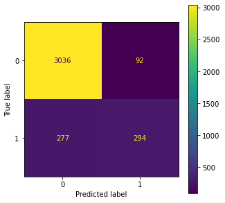

```python
# Create and plot confusion matrix
cm = confusion_matrix(y_test, y_pred, labels=rf.classes_)


disp = ConfusionMatrixDisplay(confusion_matrix=cm,
                              display_labels=rf.classes_)
disp.plot()

fig = disp.ax_.get_figure()
fig.set_figwidth(5)
fig.set_figheight(5)
```

#### Baseline Summary:

As we can see, the imbalanced target class requires some refinement in order to hopefully improve model performance. Scoring of the dominant class, `False/0`, is very good due to how many instances it contains - scoring of the minority class `True/1` is poor because there are fewer observations to train the model on.

As a result of this observation, we can look into the use of undersampling and oversampling techniques on the majority/minority class in our target feature. This will hopefully provide a more even ratio between class frequency, and provide a better scoring model.

### ML Step 3: Mitigate Class Imbalance

**Class Imbalance Resources**

- https://machinelearningmastery.com/what-is-imbalanced-classification/
- https://machinelearningmastery.com/tactics-to-combat-imbalanced-classes-in-your-machine-learning-dataset/
- https://machinelearningmastery.com/smote-oversampling-for-imbalanced-classification/

```python
# imblearn pipeline
from imblearn.pipeline import Pipeline as im_Pipeline


# Over Sample Tools
from imblearn.over_sampling import RandomOverSampler, SMOTE, ADASYN, BorderlineSMOTE, KMeansSMOTE, SVMSMOTE

# Under sample Tools
from imblearn.under_sampling import ClusterCentroids, CondensedNearestNeighbour, EditedNearestNeighbours, RepeatedEditedNearestNeighbours, AllKNN, InstanceHardnessThreshold, NearMiss, NeighbourhoodCleaningRule, OneSidedSelection, RandomUnderSampler, TomekLinks

# combined tools
from imblearn.combine import SMOTEENN, SMOTETomek
```

```python
## Re-Initialize Training/Testing splits to double ensure pipeline integrity
X_train, X_test, y_train, y_test = train_test_split(X, y, test_size=0.3, random_state=1424)
```

```python
# create pre-processor pipeline containing numeric and categorical transformers
preprocessor = ColumnTransformer(
    transformers=[
        ('num', numeric_transformer, numeric_features),
        ('cat', categorical_transformer, categorical_features)
                ])
```

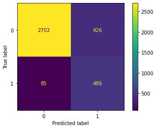

```python
# instantiate model with pipeline steps
rf = im_Pipeline(steps=[
                  ('preprocessor', preprocessor), # already instantiated
                  ('oversample', SMOTE(random_state=1424, sampling_strategy=0.2)),
                  ('undersample', RandomUnderSampler(random_state=1424, sampling_strategy=1)),
                  ('classifier', RandomForestClassifier(random_state=1424))
                    ])

# Fit model with pipeline steps to training data
rf.fit(X_train, y_train);

# Make predictions
y_pred = rf.predict(X_test)

# Create and plot confusion matrix
cm = confusion_matrix(y_test, y_pred, labels=rf.classes_)
disp = ConfusionMatrixDisplay(confusion_matrix=cm,
                              display_labels=rf.classes_)
disp.plot();
```

```python
# get classification report
print(classification_report(y_test, y_pred))
```

```
              precision    recall  f1-score   support

           0       0.97      0.86      0.91      3128
           1       0.53      0.85      0.66       571

    accuracy                           0.86      3699
   macro avg       0.75      0.86      0.78      3699
weighted avg       0.90      0.86      0.87      3699
```

**Resampling Summary** We used a researched and proven method of combining SMOTE oversampling over the minority class `True/` with an undersample method of RandomUndersampler on the majority class `False/0`.  
We note that our model can now predict class `True` with much greater accuracy, though this comes at the cost of reduced accuracy in the opposing class. We evaluate this tradeoff as acceptable, as we're primarily interesting in identifying customer patterns that lead to a sale, rather than customer patterns that lead to no sale.

Reference: https://machinelearningmastery.com/combine-oversampling-and-undersampling-for-imbalanced-classification/

## ML Step 4: Gridsearch all classifier to find estimator w/ optimal performance for our use case

Rather than manually pick well known classifiers from the sklearn library and testing them, we can import a list of all classifier type estimators and then use gridsearch to get an idea of which estimators perform the best. First, we'll get a list of available classifiers in SciKit-Learn, and when plug them into GridSearCV to identify which classifier works best with our dataset.

```python
## make sklearn structures human readable

# Get all classification models
from sklearn.utils import all_estimators

# create object holding all classifiers
estimators = all_estimators(type_filter='classifier')

# split object into pieces
classifier = [tup[0] for tup in estimators]
class_type = [tup[1] for tup in estimators]

# create dataframe with 2 columns from pieces
classification_models = pd.DataFrame(data=zip(classifier, class_type))

# rename dataframe coluns
classification_models = classification_models.rename(columns={0:'classifier', 1:'metadata'})

# force to string to enable str.split
classification_models.metadata = classification_models.metadata.astype('string')

# split on '.' and extract only index [1]
classification_models['family'] = classification_models['metadata'].str.split('.', expand=True)[1]
```

```python
# View a sample of the available models
classification_models[['family','classifier']].sort_values(by='family')
```

|  | family | classifier |
| --- | --- | --- |
| 3 | calibration | CalibratedClassifierCV |
| 32 | discriminant_analysis | QuadraticDiscriminantAnalysis |
| 18 | discriminant_analysis | LinearDiscriminantAnalysis |
| 8 | dummy | DummyClassifier |
| 0 | ensemble | AdaBoostClassifier |
| 34 | ensemble | RandomForestClassifier |
| 39 | ensemble | StackingClassifier |
| 14 | ensemble | HistGradientBoostingClassifier |
| 13 | ensemble | GradientBoostingClassifier |
| 10 | ensemble | ExtraTreesClassifier |
| 40 | ensemble | VotingClassifier |
| 1 | ensemble | BaggingClassifier |
| 12 | gaussian_process | GaussianProcessClassifier |
| 20 | linear_model | LogisticRegression |
| 37 | linear_model | SGDClassifier |
| 36 | linear_model | RidgeClassifierCV |
| 35 | linear_model | RidgeClassifier |
| 31 | linear_model | Perceptron |
| 30 | linear_model | PassiveAggressiveClassifier |
| 21 | linear_model | LogisticRegressionCV |
| 29 | multiclass | OutputCodeClassifier |
| 28 | multiclass | OneVsRestClassifier |
| 27 | multiclass | OneVsOneClassifier |
| 5 | multioutput | ClassifierChain |
| 23 | multioutput | MultiOutputClassifier |
| 2 | naive_bayes | BernoulliNB |
| 11 | naive_bayes | GaussianNB |
| 24 | naive_bayes | MultinomialNB |
| 4 | naive_bayes | CategoricalNB |
| 6 | naive_bayes | ComplementNB |
| 33 | neighbors | RadiusNeighborsClassifier |
| 15 | neighbors | KNeighborsClassifier |
| 25 | neighbors | NearestCentroid |
| 22 | neural_network | MLPClassifier |
| 17 | semi_supervised | LabelSpreading |
| 16 | semi_supervised | LabelPropagation |
| 19 | svm | LinearSVC |
| 38 | svm | SVC |
| 26 | svm | NuSVC |
| 9 | tree | ExtraTreeClassifier |
| 7 | tree | DecisionTreeClassifier |

```python
# get the number of classifier models
classification_models.shape
```

```
(41, 3)
```

there are 41 classifiers that we can use gridsearch to evaluate

```python
# Import all 41 classifiers
from sklearn.ensemble import AdaBoostClassifier, RandomForestClassifier, StackingClassifier,HistGradientBoostingClassifier,GradientBoostingClassifier, ExtraTreesClassifier, VotingClassifier, BaggingClassifier

from sklearn.linear_model import LogisticRegression, SGDClassifier, RidgeClassifierCV, RidgeClassifier, Perceptron, PassiveAggressiveClassifier, LogisticRegressionCV
from sklearn.naive_bayes import BernoulliNB, GaussianNB, MultinomialNB, CategoricalNB, ComplementNB
from sklearn.neighbors import RadiusNeighborsClassifier, KNeighborsClassifier, NearestCentroid

from sklearn.svm import LinearSVC, SVC, NuSVC
from sklearn.tree import ExtraTreeClassifier, DecisionTreeClassifier

from sklearn.neural_network import MLPClassifier
from sklearn.calibration import CalibratedClassifierCV
from sklearn.gaussian_process import GaussianProcessClassifier
from sklearn.discriminant_analysis import QuadraticDiscriminantAnalysis,LinearDiscriminantAnalysis

# Custom scoring tools
from sklearn.metrics import f1_score, make_scorer
from sklearn import model_selection
from sklearn.model_selection import GridSearchCV, StratifiedKFold, RepeatedStratifiedKFold
```

```python
# Gridsearch setup for classifier search

# instantiate model with pipeline steps
model_holder = im_Pipeline(steps=[
                  ('preprocessor', preprocessor),
                  ('oversample', SMOTE(random_state=1424, sampling_strategy=0.2)),
                  ('undersample', RandomUnderSampler(random_state=1424, sampling_strategy=1)),
                  ('classifier', RandomForestClassifier(random_state=1424))
                    ])

model_search = [
                # ensemble
                {'classifier': [AdaBoostClassifier()]},
                {'classifier': [RandomForestClassifier()]},
                #{'classifier': [StackingClassifier()]},
                {'classifier': [HistGradientBoostingClassifier()]},
                {'classifier': [GradientBoostingClassifier()]},
                {'classifier': [ExtraTreesClassifier()]},
                #{'classifier': [VotingClassifier()]},
                {'classifier': [BaggingClassifier()]},
                # linear_model
                {'classifier': [LogisticRegression()]},
                {'classifier': [SGDClassifier()]},
                {'classifier': [RidgeClassifierCV()]},
                {'classifier': [RidgeClassifier()]},
                {'classifier': [Perceptron()]},
                {'classifier': [PassiveAggressiveClassifier()]},
                {'classifier': [LogisticRegressionCV()]},
                # naive_bayes
                {'classifier': [BernoulliNB()]},
                {'classifier': [GaussianNB()]},
                {'classifier': [MultinomialNB()]},
                {'classifier': [CategoricalNB()]},
                {'classifier': [ComplementNB()]},
                # neighbors
                {'classifier': [RadiusNeighborsClassifier()]},
                {'classifier': [KNeighborsClassifier()]},
                {'classifier': [NearestCentroid()]},
                # svm
                {'classifier': [LinearSVC()]},
                {'classifier': [SVC()]},
                {'classifier': [NuSVC()]},
                # tree
                {'classifier': [ExtraTreeClassifier()]},
                {'classifier': [DecisionTreeClassifier()]},
                # neural_network
                {'classifier': [MLPClassifier()]},
                # calibration
                {'classifier': [CalibratedClassifierCV()]},
                # gaussian_process
                {'classifier': [GaussianProcessClassifier()]},
                # discriminant_analysis
                {'classifier': [QuadraticDiscriminantAnalysis()]},
                {'classifier': [LinearDiscriminantAnalysis()]}
                ]
```

**This gridsearch compares classifiers based on their weighted f1 score** This metric can provide a good overall description of classifier performance, but lacks clarity on type 1 and type 2 error rates

```python
# setup stratified k-folds for gridsearch
kfold = RepeatedStratifiedKFold(n_splits=5, random_state=1424)

# configure gridsearch parameters
## Use scoring type f1_micro
model_compare = GridSearchCV(model_holder, model_search, cv=kfold, n_jobs=-1, scoring='f1_weighted', verbose=0)

# Fit comparison model on training data
model_compare = model_compare.fit(X_train, y_train);
```

```python
# View top 10 models - F1 Weighted
model_comp_results(model_compare).head(10)
```

|  | param_classifier | mean_test_score |
| --- | --- | --- |
| 3 | GradientBoostingClassifier() | 0.874 |
| 1 | RandomForestClassifier() | 0.871 |
| 22 | SVC() | 0.870 |
| 0 | AdaBoostClassifier() | 0.869 |
| 23 | NuSVC() | 0.863 |
| 5 | BaggingClassifier() | 0.863 |
| 12 | LogisticRegressionCV() | 0.862 |
| 6 | LogisticRegression() | 0.857 |
| 21 | LinearSVC() | 0.849 |
| 27 | CalibratedClassifierCV() | 0.844 |

`GradientBoostingClassifier` performs best when targeting Weighted F1 score

```python
## Run again using recall scoring for recall optimization

# setup stratified k-folds for gridsearch
kfold = RepeatedStratifiedKFold(n_splits=5, random_state=1424)

# configure gridsearch parameters
model_compare = GridSearchCV(model_holder, model_search, cv=kfold, n_jobs=-1, scoring='recall_macro')

# Fit comparison model on training data
model_compare = model_compare.fit(X_train, y_train)
```

```python
model_comp_results(model_compare).head(5)
```

|  | param_classifier | mean_test_score |
| --- | --- | --- |
| 1 | RandomForestClassifier() | 0.854 |
| 3 | GradientBoostingClassifier() | 0.854 |
| 0 | AdaBoostClassifier() | 0.838 |
| 5 | BaggingClassifier() | 0.835 |
| 22 | SVC() | 0.827 |

**Gridsearch summary:**  
We note that depending on the scoring target used, difference classifiers perform better.  
When considering overall prediction performance(f1 weighted), `GradientBoostingClassifier` scores highly. However, when targeting best performance when predicting our target label `True/1`, `RandomForestClassifier` performs best. We'll compare these quickly side by side, to get a sense of which model is best for our use case.

Let's verify this by comparing the confusion matrices of both classifiers after fitting and making predictions.

**Evaluate Best Model for F1 score**

```python
# Evaluate GradientBoostingClassifer
rf_f1 = im_Pipeline(steps=[
                  ('preprocessor', preprocessor),
                  ('oversample', SMOTE(random_state=1424, sampling_strategy=0.2)),
                  ('undersample', RandomUnderSampler(random_state=1424, sampling_strategy=1)),
                  ('classifier', GradientBoostingClassifier(random_state=1424))
                    ])

# Fit model with pipeline steps to training data
rf_f1.fit(X_train, y_train);

# Make predictions
y_pred_f1 = rf_f1.predict(X_test)

# get classification report
print(classification_report(y_test, y_pred_f1))
```

```
              precision    recall  f1-score   support

           0       0.97      0.87      0.91      3128
           1       0.54      0.84      0.65       571

    accuracy                           0.86      3699
   macro avg       0.75      0.85      0.78      3699
weighted avg       0.90      0.86      0.87      3699
```

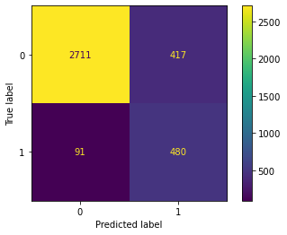

```python
# Create and plot confusion matrix
cm = confusion_matrix(y_test, y_pred_f1, labels=rf_f1.classes_)
disp = ConfusionMatrixDisplay(confusion_matrix=cm,
                              display_labels=rf_f1.classes_)
disp.plot();
```

We see a 16% error rate (91/571) in class 1 predictions when using GradientBoostingClassifier.

**Evaluate Model with best Recall Score**

```python
rf_recall_x = im_Pipeline(steps=[
                  ('preprocessor', preprocessor),
                  ('oversample', SMOTE(random_state=1424, sampling_strategy=0.2)),
                  ('undersample', RandomUnderSampler(random_state=1424, sampling_strategy=1)),
                  ('classifier', RandomForestClassifier(random_state=1424))
                    ])

# Fit model with pipeline steps to training data
rf_recall_x.fit(X_train, y_train);

# Make predictions
y_pred_recall = rf_recall_x.predict(X_test)

# get classification report
print(classification_report(y_test, y_pred_recall))
```

```
              precision    recall  f1-score   support

           0       0.97      0.86      0.91      3128
           1       0.53      0.85      0.66       571

    accuracy                           0.86      3699
   macro avg       0.75      0.86      0.78      3699
weighted avg       0.90      0.86      0.87      3699
```

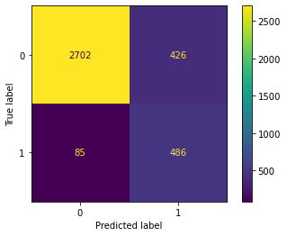

```python
# Create and plot confusion matrix
cm = confusion_matrix(y_test, y_pred_recall, labels=rf_recall_x.classes_)
disp = ConfusionMatrixDisplay(confusion_matrix=cm,
                              display_labels=rf_recall_x.classes_)
disp.plot();
```

By using the classifier that focuses on optimizing for Recall, we see that our prediction error rate for class 1, decreases to 14.8% - a slight improvement in prediction ability. But, we can also see that the error rate for class 0 predictions increased by about 1%.

Given that we're most interested in identifying consumers that are more likely to make a purchase, we find this trade-off acceptable.

```python
# Get the feature importance for the RandomForestClassifier
feats = {} # a dict to hold feature_name: feature_importance
for feature, importance in zip(X.columns, rf_recall_x.steps[3][1].feature_importances_):
    feats[feature] = importance #add the name/value pair

feats = pd.DataFrame.from_dict(feats, orient='index').reset_index().rename(columns={'index':'feature', 0: 'importance'})

feats = feats.sort_values(by='importance', ascending=False)
```

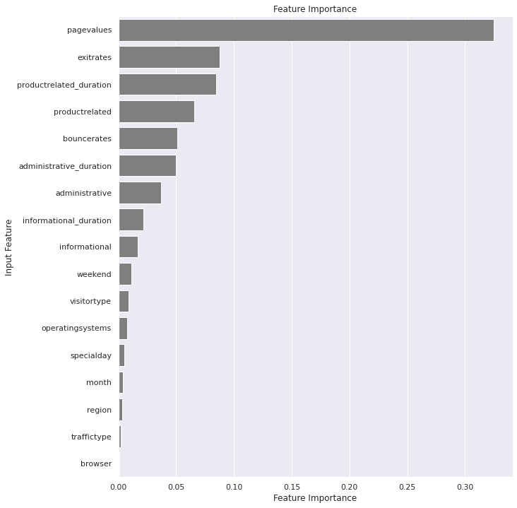

```python
# Plot config
sns.set_theme(style='darkgrid')
plt.figure(figsize=(10, 12))

# Viz Foundation
sns.barplot(y ='feature', x='importance', data = feats, color='tab:gray')

# Labeling
plt.ylabel('Input Feature')
plt.xlabel('Feature Importance')
plt.title('Feature Importance')

# Axis Settings
ax = plt.gca()

plt.show();
```

The plot displayed about gives us the feature importance of our input features, according to a RandomForestClassifier. We can see that a few features account for almost all of the decision making made by the model, while the other half of the features have little to no impact on the model.

## RFE Testing

Next, we'll use Recursive Feature Elimination to take advantage of the feature importance plot we noted previously. By using SciKit-Learn's built in RFE tool, we can add this step to our pipline and evaluate the output compared to our previous fitted model that took all available input features.

```python
from sklearn.feature_selection import RFECV
```

```python
rfe = RFECV(estimator=RandomForestClassifier(random_state=1424), min_features_to_select=1, step=1, scoring='recall_macro')

rf_rfe = im_Pipeline(steps=[
                  ('preprocessor', preprocessor),
                  ('oversample', SMOTE(random_state=1424, sampling_strategy=0.2)),
                  ('undersample', RandomUnderSampler(random_state=1424, sampling_strategy=1)),
                  ('RFE', rfe),
                  ('classifier', RandomForestClassifier(random_state=1424))
                    ])

# Fit model with pipeline steps to training data
rf_rfe.fit(X_train, y_train);

# Make predictions
y_pred_rfe = rf_rfe.predict(X_test)

# get classification report
print(classification_report(y_test, y_pred_rfe))
```

```
              precision    recall  f1-score   support

           0       0.97      0.86      0.91      3128
           1       0.53      0.85      0.65       571

    accuracy                           0.86      3699
   macro avg       0.75      0.86      0.78      3699
weighted avg       0.90      0.86      0.87      3699
```

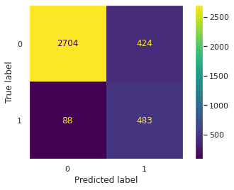

```python
# Create and plot confusion matrix
cm = confusion_matrix(y_test, y_pred_rfe, labels=rf_rfe.classes_)
disp = ConfusionMatrixDisplay(confusion_matrix=cm,
                              display_labels=rf_rfe.classes_)
disp.plot();
plt.grid(False)
```

Interestingly, we can see that using RFE to evaluate the best combination of input features to select results in a higher error rate when predicting class 1. Because of this, we'll remove RFE from our pipeline, and move on to the use of class-weights to try improving model performance based on our stated usecase.

### Class Weight Gridsearch Testing

```python
rf = im_Pipeline(steps=[
                  ('preprocessor', preprocessor),
                  ('oversample', SMOTE(random_state=1424, sampling_strategy=0.2)),
                  ('undersample', RandomUnderSampler(random_state=1424, sampling_strategy=1)),
                  ('classifier', RandomForestClassifier(random_state=1424))
                    ])
```

```python
# Set weights search space
class_weight = np.arange(0, 100, 0.05)

# define search space
param_grid = {
      'classifier__class_weight': [{0:x, 1:1.0-x} for x in class_weight]
                }

# define evaluation
cv = RepeatedStratifiedKFold(n_splits=5, n_repeats=1, random_state=1424)

# define search
search = GridSearchCV(rf, param_grid, n_jobs=-1, cv=cv, verbose=1, scoring='recall_macro')

# execute search
result = search.fit(X_train, y_train)
```

```
Fitting 5 folds for each of 2000 candidates, totalling 10000 fits
```

```python
# # summarize result
print('Best Score: %s' % result.best_score_)
print('Best Hyperparameters: %s' % result.best_params_)
```

```
Best Score: 0.8534418884071515
Best Hyperparameters: {'classifier__class_weight': {0: 0.15000000000000002, 1: 0.85}}
```

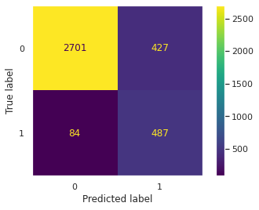

```python
rf_recall = im_Pipeline(steps=[
                  ('preprocessor', preprocessor),
                  ('oversample', SMOTE(random_state=1424, sampling_strategy=0.2)),
                  ('undersample', RandomUnderSampler(random_state=1424, sampling_strategy=1)),
                  ('classifier', RandomForestClassifier(random_state=1424, class_weight={0: 0.15, 1: 0.85}))
                    ])

# Fit model with pipeline steps to training data
rf_recall.fit(X_train, y_train);

# Make predictions
y_pred_recall = rf_recall.predict(X_test)

# Create and plot confusion matrix
cm = confusion_matrix(y_test, y_pred_recall, labels=rf_recall.classes_)
disp = ConfusionMatrixDisplay(confusion_matrix=cm,
                              display_labels=rf_recall.classes_)
disp.plot();
plt.grid(False)
```

While using class weights doesn't improve our ability to predict class `0` we do improve the class `1` prediction rate a bit.

```python
# get classification report
print(classification_report(y_test, y_pred_recall))
```

```
              precision    recall  f1-score   support

           0       0.97      0.86      0.91      3128
           1       0.53      0.85      0.66       571

    accuracy                           0.86      3699
   macro avg       0.75      0.86      0.78      3699
weighted avg       0.90      0.86      0.87      3699
```

Using Class weights doesn't appear to positively affect model performance.

## GridSearch `RandomForestClassifier` parameters

```python
rf = im_Pipeline(steps=[
                  ('preprocessor', preprocessor),
                  ('oversample', SMOTE(random_state=1424, sampling_strategy=0.2)),
                  ('undersample', RandomUnderSampler(random_state=1424, sampling_strategy=1)),
                  ('classifier', RandomForestClassifier(random_state=1424, class_weight={0: 0.15, 1: 0.85}))
                    ])
```

```python
# Available tuning parameters
# https://scikit-learn.org/stable/modules/generated/sklearn.ensemble.RandomForestClassifier

n_estimators = np.arange(290, 320, 5)
criterion = ['gini']
max_depth = np.arange(1, 41, 5)
min_samples_split = np.arange(38, 45, 1)
min_samples_leaf = np.arange(1, 51, 10)
min_weight_fraction_leaf = np.arange(0.1, 1.0, 0.1)
max_features = np.arange(1, 100, 20)
max_leaf_nodes = np.arange(0, 51, 10)
min_impurity_decrease = np.arange(0.1, 1.0, 0.1)
bootstrap = [True, False]
ccp_alpha = np.arange(1, 10, 2)
max_samples = np.arange(1, 100, 20)
class_weight = np.arange(0, 100, 0.05)


# define search space
param_grid = {
      'classifier__n_estimators': n_estimators,
      'classifier__criterion': criterion,
      'classifier__max_depth': max_depth,
      #'classifier__min_samples_split': min_samples_split,
      #'classifier__min_samples_leaf': min_samples_leaf,
      #'classifier__min_weight_fraction_leaf': min_weight_fraction_leaf,
      'classifier__max_features': max_features,
      #'classifier__max_leaf_nodes': max_leaf_nodes,
      #'classifier__min_impurity_decrease': min_impurity_decrease,
      'classifier__bootstrap': bootstrap,
      'classifier__class_weight': [{0:x, 1:1.0-x} for x in class_weight],
      #'classifier__ccp_alpha': ccp_alpha,
      'classifier__max_samples': max_samples
                }

# define evaluation
cv = RepeatedStratifiedKFold(n_splits=2, n_repeats=1, random_state=1424)

# define search
search = GridSearchCV(rf, param_grid, n_jobs=-1, cv=cv, verbose=1, scoring='recall_macro')

# execute search
#result = search.fit(X_train, y_train)

# Fitting 2 folds for each of 4800000 candidates, totalling 9600000 fits
# Ran for 1308 Minutes
```

[output not shown]

[output not shown]

```python
# # summarize result
#print('Best Score: %s' % result.best_score_)
#print('Best Hyperparameters: %s' % result.best_params_)

# output:
#EDA_notebook.htmlBest Score: 0.8511271634880228
#Best Hyperparameters: {'classifier__bootstrap': True, 'classifier__class_weight': {0: 0.55, 1: 0.44999999999999996}, 'classifier__criterion': 'gini', 'classifier__max_depth': 6, 'classifier__max_features': 41, 'classifier__max_samples': 81, 'classifier__n_estimators': 300}
```

[output not shown]

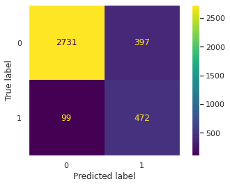

```python
rf_recall = im_Pipeline(steps=[
                  ('preprocessor', preprocessor),
                  ('oversample', SMOTE(random_state=1424, sampling_strategy=0.2)),
                  ('undersample', RandomUnderSampler(random_state=1424, sampling_strategy=1)),
                  ('classifier', RandomForestClassifier(random_state=1424,
                                                        bootstrap=True,
                                                        class_weight={0: 0.55, 1: 0.449},
                                                        criterion='gini',
                                                        max_depth=6,
                                                        max_features=41,
                                                        max_samples=81,
                                                        n_estimators=300
                                                          ))
                    ])

# Fit model with pipeline steps to training data
rf_recall.fit(X_train, y_train);

# Make predictions
y_pred_recall = rf_recall.predict(X_test)

# Create and plot confusion matrix
cm = confusion_matrix(y_test, y_pred_recall, labels=rf_recall.classes_)
disp = ConfusionMatrixDisplay(confusion_matrix=cm,
                              display_labels=rf_recall.classes_)
disp.plot();
plt.grid(False)
```

Inspite of 21 hours of hyper-parameter tuning, the model was not able to perform better than out best performing iteration.